# Predicting Project Completion Time

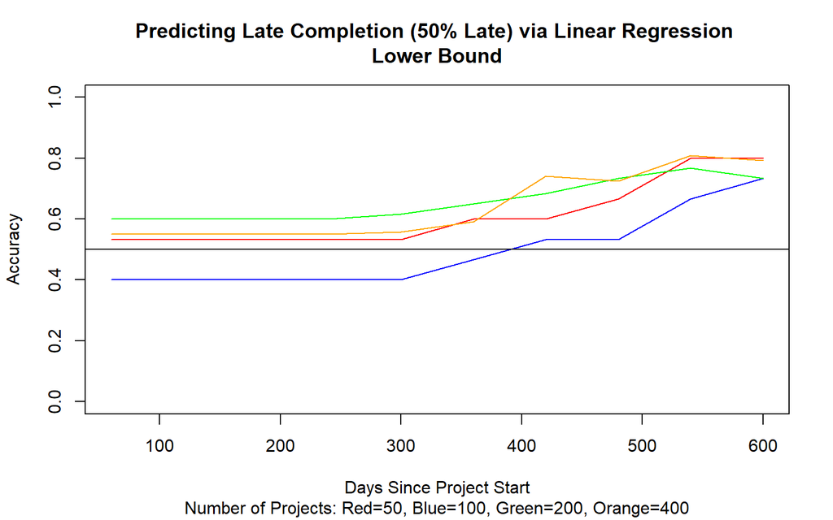

```r
par(mar = c(5, 4, 4, 2) + 0.1)

plot(x=days, y=d_lrlwr_acc[,1], type="l", col="red", ylim=c(0,1), xlab="Days Since Project Start", ylab="Accuracy"
     ,main="Predicting Late Completion (50% Late) via Linear Regression \nLower Bound", sub="Number of Projects: Red=50, Blue=100, Green=200, Orange=400")
lines(x=days, y=d_lrlwr_acc[,2], col="blue")
lines(x=days, y=d_lrlwr_acc[,3], col="green")
lines(x=days, y=d_lrlwr_acc[,4], col="orange")
abline(h=.5)
```

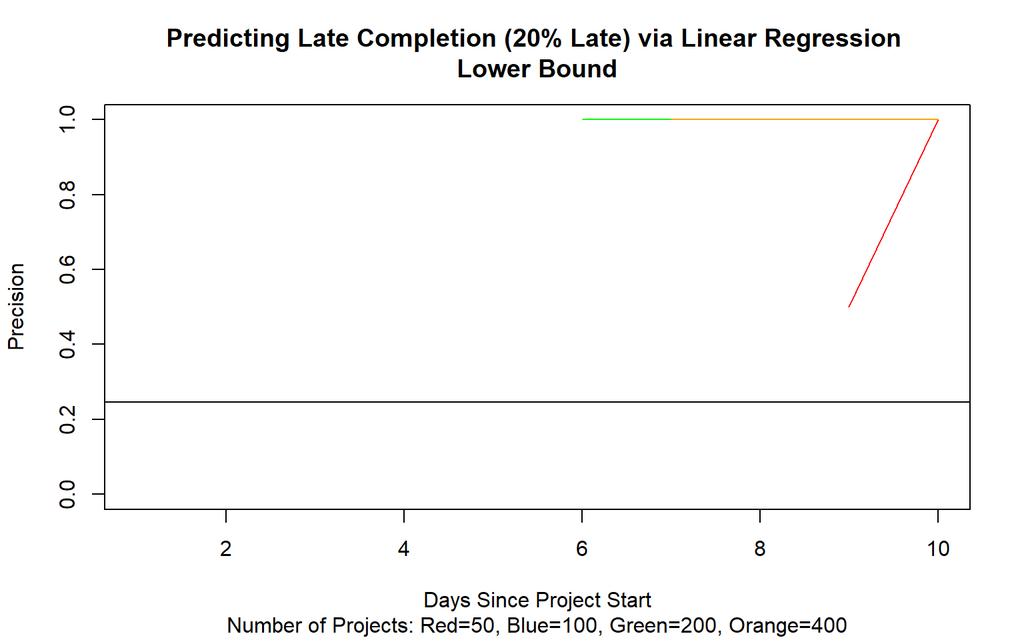

```r
plot(d_lrlwr_prec[,1], type="l", col="red", ylim=c(0,1), xlab="Days Since Project Start", ylab="Precision"
     ,main="Predicting Late Completion (20% Late) via Linear Regression \nLower Bound", sub="Number of Projects: Red=50, Blue=100, Green=200, Orange=400")
lines(d_lrlwr_prec[,2], col="blue")
lines(d_lrlwr_prec[,3], col="green")
lines(d_lrlwr_prec[,4], col="orange")
abline(h=prec_base)
```

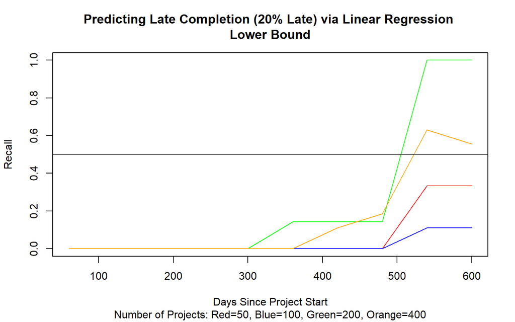

```r
plot(x=days, y=d_lrlwr_rec[,1], type="l", col="red", ylim=c(0,1), xlab="Days Since Project Start", ylab="Recall"
     ,main="Predicting Late Completion (20% Late) via Linear Regression \nLower Bound", sub="Number of Projects: Red=50, Blue=100, Green=200, Orange=400")
lines(x=days, y=d_lrlwr_rec[,2], col="blue")
lines(x=days, y=d_lrlwr_rec[,3], col="green")
lines(x=days, y=d_lrlwr_rec[,4], col="orange")
abline(h=.5)
```

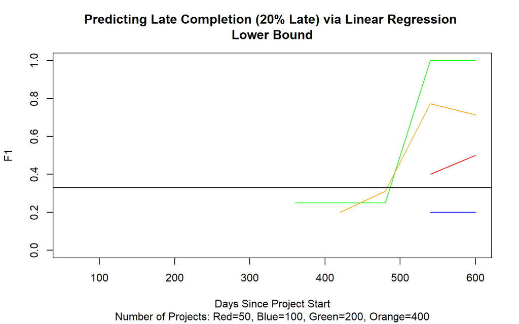

```r
plot(x=days, y=d_lrlwr_f1[,1], type="l", col="red", ylim=c(0,1), xlab="Days Since Project Start", ylab="F1"
     ,main="Predicting Late Completion (20% Late) via Linear Regression \nLower Bound", sub="Number of Projects: Red=50, Blue=100, Green=200, Orange=400")
lines(x=days, y=d_lrlwr_f1[,2], col="blue")
lines(x=days, y=d_lrlwr_f1[,3], col="green")
lines(x=days, y=d_lrlwr_f1[,4], col="orange")
abline(h=prec_base/(prec_base+.5))
```

```r
par(mar = c(0,0,0,0))
plot(c(0, 1), c(0, 1), ann = F, bty = 'n', type = 'n', xaxt = 'n', yaxt = 'n')
text(x = 0.5, y = 0.5, "Begin Boosted Decision Tree Plots", cex = 1.6, col = "black")
```

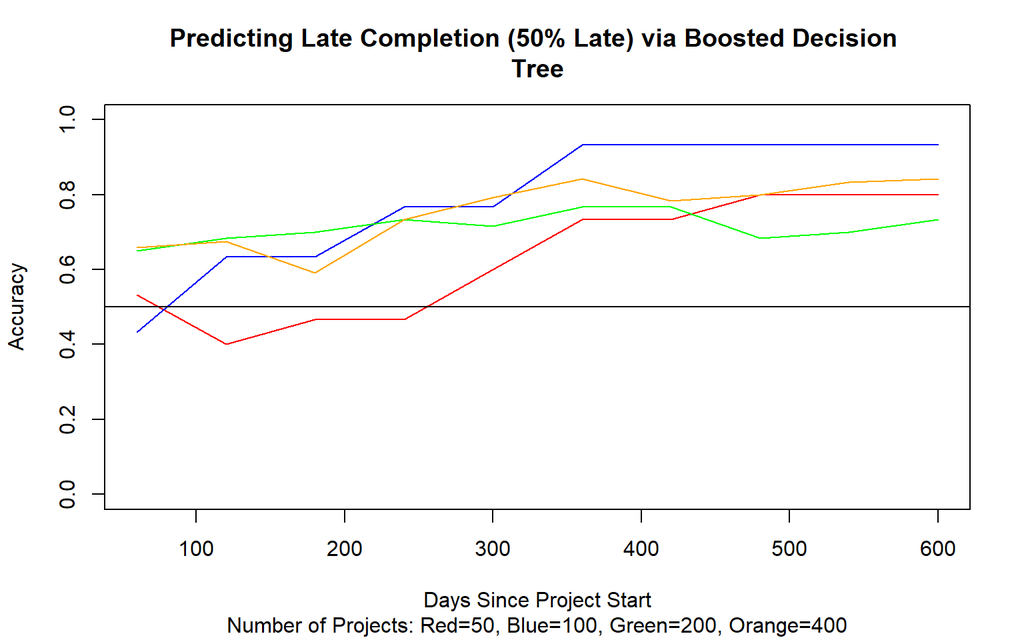

```r
par(mar = c(5, 4, 4, 2) + 0.1)

plot(x=days, y=d_bdt_acc[,1], type="l", col="red", ylim=c(0,1), xlab="Days Since Project Start", ylab="Accuracy"
     ,main="Predicting Late Completion (50% Late) via Boosted Decision \nTree", sub="Number of Projects: Red=50, Blue=100, Green=200, Orange=400")
lines(x=days, y=d_bdt_acc[,2], col="blue")
lines(x=days, y=d_bdt_acc[,3], col="green")
lines(x=days, y=d_bdt_acc[,4], col="orange")
abline(h=.5)
```

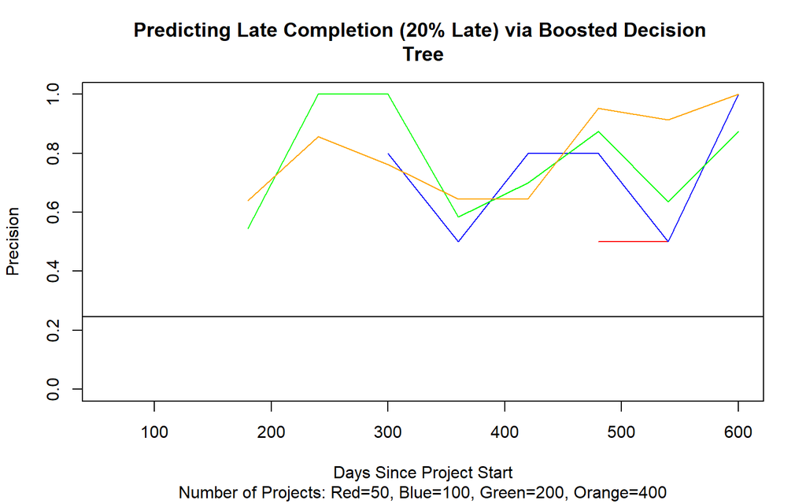

```r
plot(x=days, y=d_bdt_prec[,1], type="l", col="red", ylim=c(0,1), xlab="Days Since Project Start", ylab="Precision"
     ,main="Predicting Late Completion (20% Late) via Boosted Decision \nTree", sub="Number of Projects: Red=50, Blue=100, Green=200, Orange=400")
lines(x=days, y=d_bdt_prec[,2], col="blue")
lines(x=days, y=d_bdt_prec[,3], col="green")
lines(x=days, y=d_bdt_prec[,4], col="orange")
abline(h=prec_base)
```

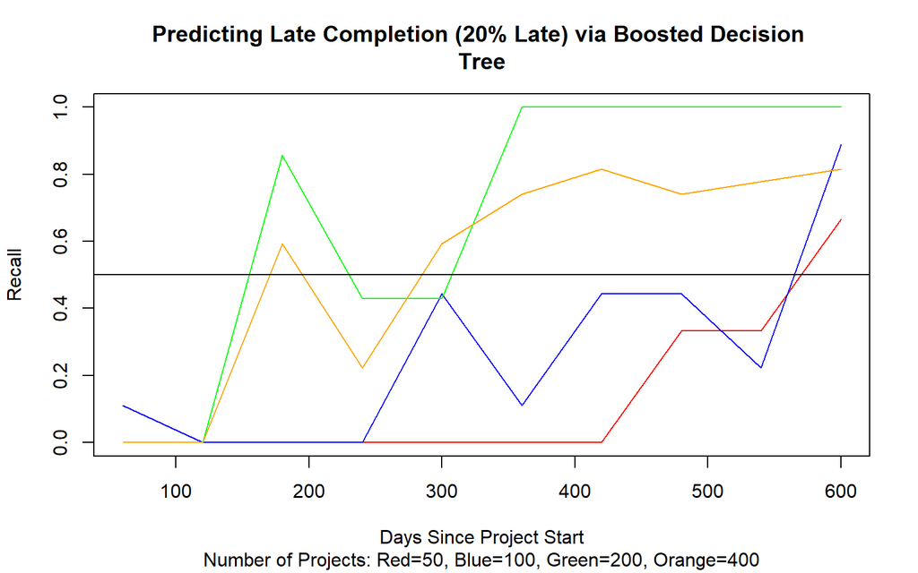

```r
plot(x=days, y=d_bdt_rec[,1], type="l", col="red", ylim=c(0,1), xlab="Days Since Project Start", ylab="Recall"
     ,main="Predicting Late Completion (20% Late) via Boosted Decision \nTree", sub="Number of Projects: Red=50, Blue=100, Green=200, Orange=400")
lines(x=days, y=d_bdt_rec[,2], col="blue")
lines(x=days, y=d_bdt_rec[,3], col="green")
lines(x=days, y=d_bdt_rec[,4], col="orange")
abline(h=.5)
```

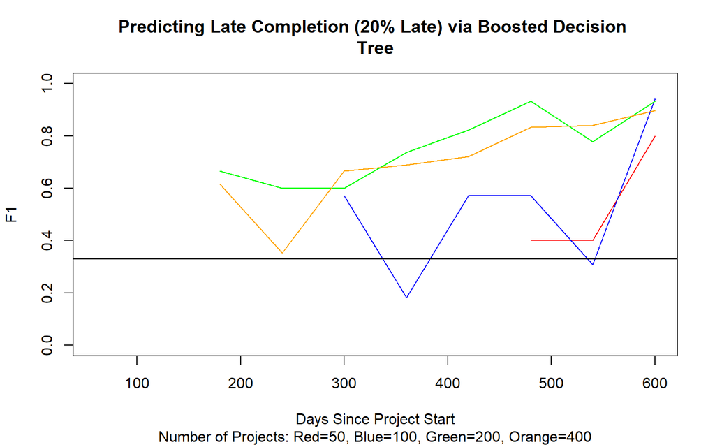

```r
plot(x=days, y=d_bdt_f1[,1], type="l", col="red", ylim=c(0,1), xlab="Days Since Project Start", ylab="F1"
     ,main="Predicting Late Completion (20% Late) via Boosted Decision \nTree", sub="Number of Projects: Red=50, Blue=100, Green=200, Orange=400")
lines(x=days, y=d_bdt_f1[,2], col="blue")
lines(x=days, y=d_bdt_f1[,3], col="green")
lines(x=days, y=d_bdt_f1[,4], col="orange")
abline(h=prec_base/(prec_base+.5))
```

```r
par(mar = c(0,0,0,0))
plot(c(0, 1), c(0, 1), ann = F, bty = 'n', type = 'n', xaxt = 'n', yaxt = 'n')
text(x = 0.5, y = 0.5, "Begin Logistic Regression Plots", cex = 1.6, col = "black")
```

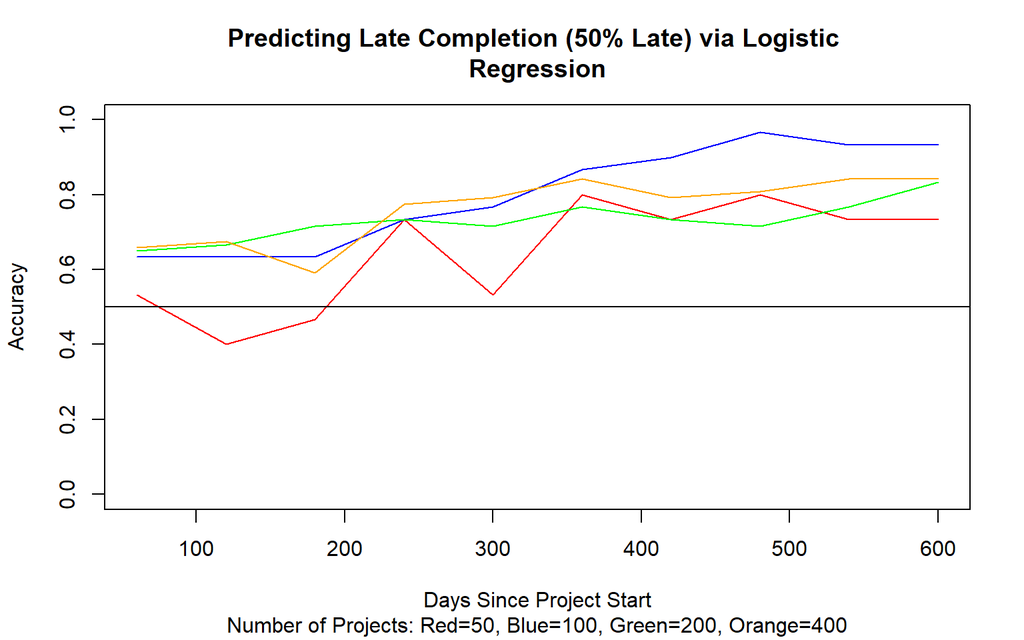

```r
par(mar = c(5, 4, 4, 2) + 0.1)

plot(x=days, y=d_log_acc[,1], type="l", col="red", ylim=c(0,1), xlab="Days Since Project Start", ylab="Accuracy"
     ,main="Predicting Late Completion (50% Late) via Logistic \nRegression", sub="Number of Projects: Red=50, Blue=100, Green=200, Orange=400")
lines(x=days, y=d_log_acc[,2], col="blue")
lines(x=days, y=d_log_acc[,3], col="green")
lines(x=days, y=d_log_acc[,4], col="orange")
abline(h=.5)
```

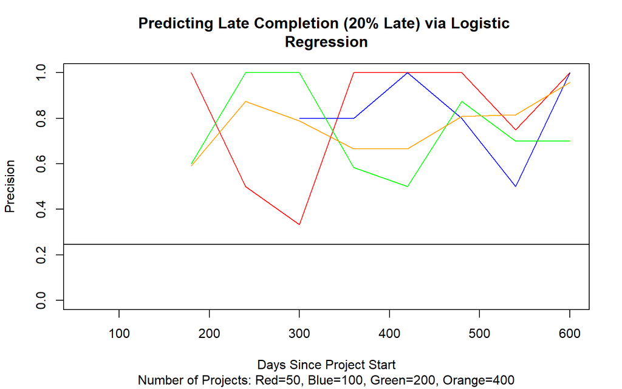

```r
plot(x=days, y=d_log_prec[,1], type="l", col="red", ylim=c(0,1), xlab="Days Since Project Start", ylab="Precision"
     ,main="Predicting Late Completion (20% Late) via Logistic \nRegression", sub="Number of Projects: Red=50, Blue=100, Green=200, Orange=400")
lines(x=days, y=d_log_prec[,2], col="blue")
lines(x=days, y=d_log_prec[,3], col="green")
lines(x=days, y=d_log_prec[,4], col="orange")
abline(h=prec_base)
```

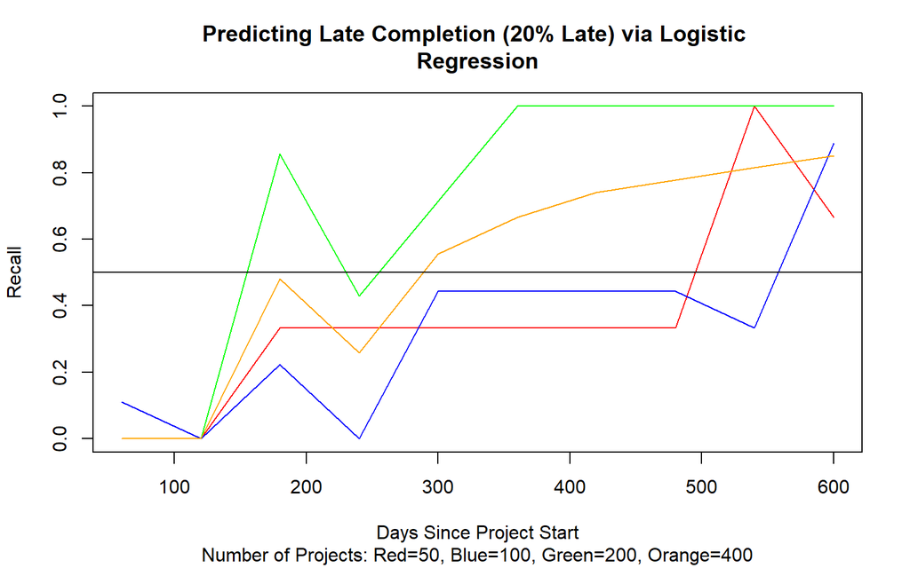

```r
plot(x=days, y=d_log_rec[,1], type="l", col="red", ylim=c(0,1), xlab="Days Since Project Start", ylab="Recall"
     ,main="Predicting Late Completion (20% Late) via Logistic \nRegression", sub="Number of Projects: Red=50, Blue=100, Green=200, Orange=400")
lines(x=days, y=d_log_rec[,2], col="blue")
lines(x=days, y=d_log_rec[,3], col="green")
lines(x=days, y=d_log_rec[,4], col="orange")
abline(h=.5)
```

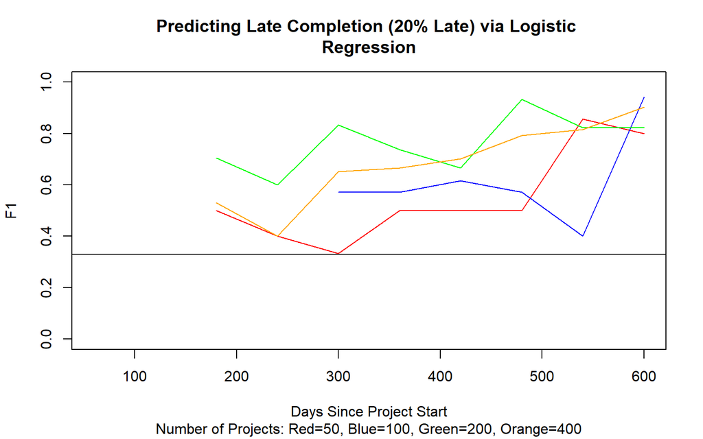

```r
plot(x=days, y=d_log_f1[,1], type="l", col="red", ylim=c(0,1), xlab="Days Since Project Start", ylab="F1"
     ,main="Predicting Late Completion (20% Late) via Logistic \nRegression", sub="Number of Projects: Red=50, Blue=100, Green=200, Orange=400")
lines(x=days, y=d_log_f1[,2], col="blue")
lines(x=days, y=d_log_f1[,3], col="green")
lines(x=days, y=d_log_f1[,4], col="orange")
abline(h=prec_base/(prec_base+.5))
```

One thing is apparent in these chart. The alternative framework produces substantially less useful Linear Regression results than the initial framework. Combining this result with what we found earlier leads us to conclude that the initial framework is the optimal strategy for dealing with this type of data.

# DCX-Specific Data

## Introduction

For the Microsoft DCX engagement, we were provided with a scenario similar to what was proposed as the basis for this framework. This data came in as weekly snapshots. This means that a single project will have a record every week noting the progress that has been made. A major concern of using this data in its current state is “overfitting”. This is an issue where a large number of records show the same patterns. This can lead to a model that predicts that particular dataset well, but does not extrapolate to other datasets well. In this case, this is caused by the fact that there are a large number of records, but a relatively small number of projects.

We also found that matching up tasks across projects needs much more work before the dataset would be viable. Microsoft provided a mapping for twelve milestones. These are very similar to the Top Summary Tasks we used in the framework. After cleansing on our side, we found four projects that could potentially be used for prediction. Since four projects is much too small a sample for our needs, we developed a way to lay our framework, and the associated test data, on top of the DCX data provided.

## Dataset Preparation

To prepare our test datasets, we first calculated the mean and standard deviation for each milestone.

```r
dcx.df <- apply(data.frame(dcx)[,-(1:3)], 2, FUN=as.numeric)
dcx.mean <- apply(dcx.df, 2, FUN=mean, na.rm=TRUE)
dcx.sd <- apply(dcx.df, 2, FUN=sd, na.rm=TRUE)

disp <- data.frame(dcx.mean, dcx.sd)
names(disp) <- c("Mean", "Standard Deviation")
row.names(disp) <- names(dcx.mean)
disp
```

|  | Mean | Standard Deviation |
| --- | --- | --- |
| Signal.Received | 0.00 | 0.00000 |
| Charter.Approved | 34.75 | 42.91367 |
| Design.Kickoff | 50.00 | 78.80990 |
| Issue.for.Construction.Documents..IFC. | 42.00 | 29.81610 |
| Construction.Start | 169.00 | 135.50277 |
| Beneficial.Use | 249.00 | NA |
| Cx.Level.3.Complete | 0.00 | NA |
| IST.Complete | 7.00 | NA |
| Security.Lockdown | 33.00 | NA |
| Turnover.to.Ops | 8.00 | NA |

[output cut: 2 more lines]

The milestones that do not have standard deviations contain only one record. Therefore, we need a way to infer what these standard deviations are. In order to do this, we find the ratio between the overall mean and the overall standard deviation. We can combine this with the mean to infer what the standard deviation of the individual milestone would be. Obviously, this is a biased approach. However, we have such little data that we must make some assumptions in order to proceed

```r
dcx.mean.overall <- mean(dcx.df, na.rm=TRUE)
dcx.sd.overall <- sd(dcx.df, na.rm=TRUE)
dcx.ratio <- dcx.sd.overall / dcx.mean.overall
dcx.sd.new <- coalesce(dcx.sd, dcx.mean*dcx.ratio)

disp <- data.frame(dcx.mean, dcx.sd.new)
names(disp) <- c("Mean", "Standard Deviation")
row.names(disp) <- names(dcx.mean)
disp
```

|  | Mean | Standard Deviation |
| --- | --- | --- |
| Signal.Received | 0.00 | 0.00000 |
| Charter.Approved | 34.75 | 42.91367 |
| Design.Kickoff | 50.00 | 78.80990 |
| Issue.for.Construction.Documents..IFC. | 42.00 | 29.81610 |
| Construction.Start | 169.00 | 135.50277 |
| Beneficial.Use | 249.00 | 386.42383 |
| Cx.Level.3.Complete | 0.00 | 0.00000 |
| IST.Complete | 7.00 | 10.86332 |
| Security.Lockdown | 33.00 | 51.21280 |
| Turnover.to.Ops | 8.00 | 12.41522 |

[output cut: 2 more lines]

The variables with standard deviations of zero would provide no value to any predictive model. Therefore, we remove them from our dataset. Then, we rename the Top Summary Tasks from our test data and scale them according to the new mean and standard deviation. This will create our new datasets.

```r
dcx.mean.final <- dcx.mean[dcx.sd.new>0]
dcx.sd.final <- dcx.sd.new[dcx.sd.new>0]

dcx50proj_init <- t50proj_pvt[,1:(length(dcx.mean.final)+1)]
dcx50proj <- data.frame(t50proj_pvt[,1])

for(i in 2:dim(dcx50proj_init)[2]){
  dcx50proj[,i] <- scale(dcx50proj_init[,i]) * dcx.sd.final[i-1] + dcx.mean.final[i-1]
}

names(dcx50proj) <- c(names(t50proj_pvt)[1], names(dcx.mean.final))

dcx100proj_init <- t100proj_pvt[,1:(length(dcx.mean.final)+1)]
dcx100proj <- data.frame(t100proj_pvt[,1])

for(i in 2:dim(dcx100proj_init)[2]){
  dcx100proj[,i] <- scale(dcx100proj_init[,i]) * dcx.sd.final[i-1] + dcx.mean.final[i-1]
}

names(dcx100proj) <- c(names(t100proj_pvt)[1], names(dcx.mean.final))

dcx200proj_init <- t200proj_pvt[,1:(length(dcx.mean.final)+1)]
dcx200proj <- data.frame(t200proj_pvt[,1])

for(i in 2:dim(dcx200proj_init)[2]){
  dcx200proj[,i] <- scale(dcx200proj_init[,i]) * dcx.sd.final[i-1] + dcx.mean.final[i-1]
}

names(dcx200proj) <- c(names(t200proj_pvt)[1], names(dcx.mean.final))

dcx400proj_init <- t400proj_pvt[,1:(length(dcx.mean.final)+1)]
dcx400proj <- data.frame(t400proj_pvt[,1])

for(i in 2:dim(dcx400proj_init)[2]){
  dcx400proj[,i] <- scale(dcx400proj_init[,i]) * dcx.sd.final[i-1] + dcx.mean.final[i-1]
}

names(dcx400proj) <- c(names(t400proj_pvt)[1], names(dcx.mean.final))

head(dcx400proj)
```

|  | ProjectNumber | Charter.Approved | Design.Kickoff | Issue.for.Construction.Documents..IFC. | Construction.Start | Beneficial.Use | IST.Complete | Security.Lockdown | Turnover.to.Ops | Colo.Ready | RTEG |
| --- | --- | --- | --- | --- | --- | --- | --- | --- | --- | --- | --- |
| 1 | 1 | 0.02589589 | 84.949697 | 47.71264 | 251.05975 | 858.40051 | 30.042271 | -11.551172 | 31.968739 | 20.735460 | 62.58569 |
| 2 | 2 | 32.95924893 | -39.205533 | 11.04172 | 72.79817 | -322.81634 | -7.781950 | -39.561968 | 20.391191 | -8.862030 | 31.23409 |
| 3 | 3 | 57.65926371 | 184.273882 | 27.08525 | -10.39057 | -287.02189 | 10.520093 | 106.094173 | 30.682344 | -15.204349 | 167.09102 |
| 4 | 4 | 24.72591067 | -6.097472 | 54.58844 | 155.98690 | 929.98942 | -2.901405 | 5.255306 | 3.668068 | 3.822609 | 73.03623 |
| 5 | 5 | -16.44078063 | 18.733574 | 29.37718 | 464.97364 | 607.83936 | 1.979140 | 44.470421 | 2.381674 | 5.936715 | -52.37017 |
| 6 | 6 | 41.19258719 | 60.118651 | 24.79331 | 203.52333 | 35.12816 | 4.419412 | 5.255306 | -1.477509 | -2.519710 | -62.82070 |

## Results

We run the same code as in the initial framework. The only modification is that we change the names of the datsets.

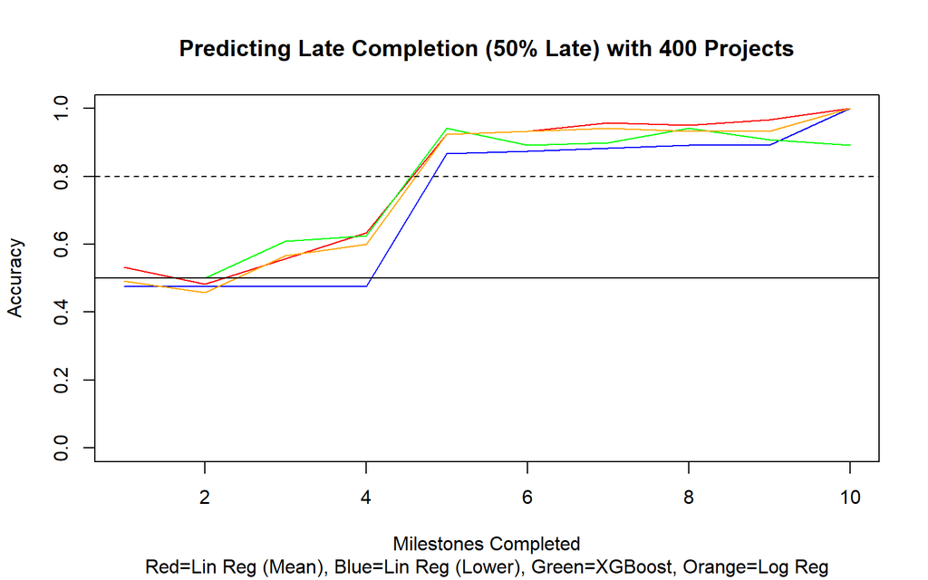

```r
plot(lravg_acc[,4], type="l", col="red", ylim=c(0,1), xlab="Milestones Completed", ylab="Accuracy"
     ,main="Predicting Late Completion (50% Late) with 400 Projects", sub="Red=Lin Reg (Mean), Blue=Lin Reg (Lower), Green=XGBoost, Orange=Log Reg")
lines(lrlwr_acc[,4], col="blue")
lines(bdt_acc[,4], col="green")
lines(log_acc[,4], col="orange")
abline(h=.5)
abline(h=.8, lty=2)
```

With a 400 project sample and a 50% “Late” threshold, we surpass 80% accuracy by Milestone 5 (Beneficial Use).

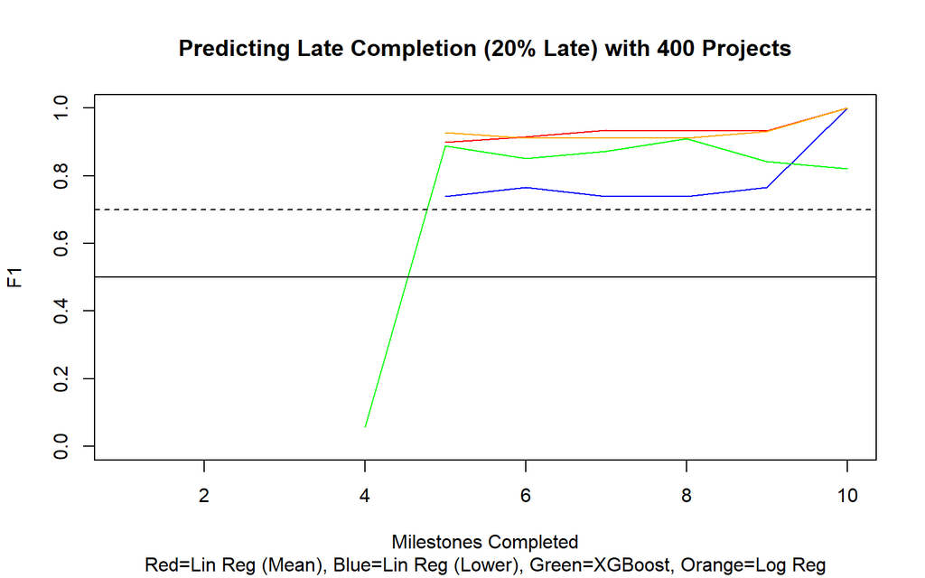

```r
plot(lravg_f1[,4], type="l", col="red", ylim=c(0,1), xlab="Milestones Completed", ylab="F1"
     ,main="Predicting Late Completion (20% Late) with 400 Projects", sub="Red=Lin Reg (Mean), Blue=Lin Reg (Lower), Green=XGBoost, Orange=Log Reg")
lines(lrlwr_f1[,4], col="blue")
lines(bdt_f1[,4], col="green")
lines(log_f1[,4], col="orange")
abline(h=.5)
abline(h=.7, lty=2)
```

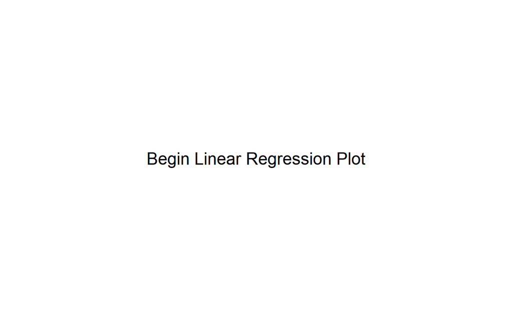

```r
par(mar = c(0,0,0,0))
plot(c(0, 1), c(0, 1), ann = F, bty = 'n', type = 'n', xaxt = 'n', yaxt = 'n')
text(x = 0.5, y = 0.5, "Begin Linear Regression Plot", cex = 1.6, col = "black")
```

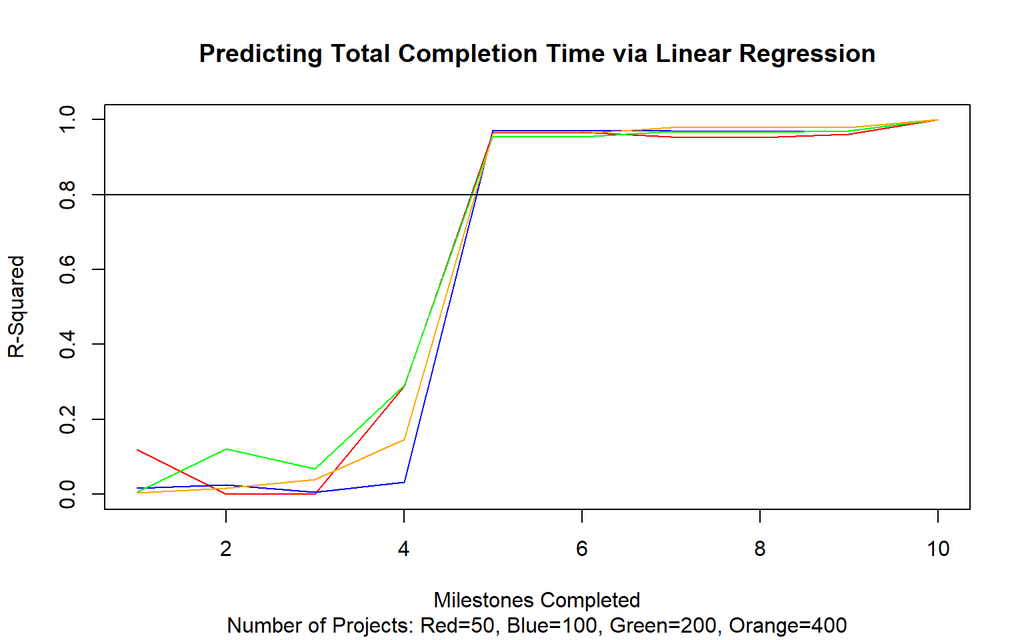

```r
par(mar = c(5, 4, 4, 2) + 0.1)

plot(r_sq[,1], type="l", col="red", ylim=c(0,1), xlab="Milestones Completed", ylab="R-Squared"
     ,main="Predicting Total Completion Time via Linear Regression", sub="Number of Projects: Red=50, Blue=100, Green=200, Orange=400")
lines(r_sq[,2], col="blue")
lines(r_sq[,3], col="green")
lines(r_sq[,4], col="orange")
abline(h=.8)
```

```r
par(mar = c(0,0,0,0))
plot(c(0, 1), c(0, 1), ann = F, bty = 'n', type = 'n', xaxt = 'n', yaxt = 'n')
text(x = 0.5, y = 0.5, "Begin Linear Regression Mean Plots", cex = 1.6, col = "black")
```

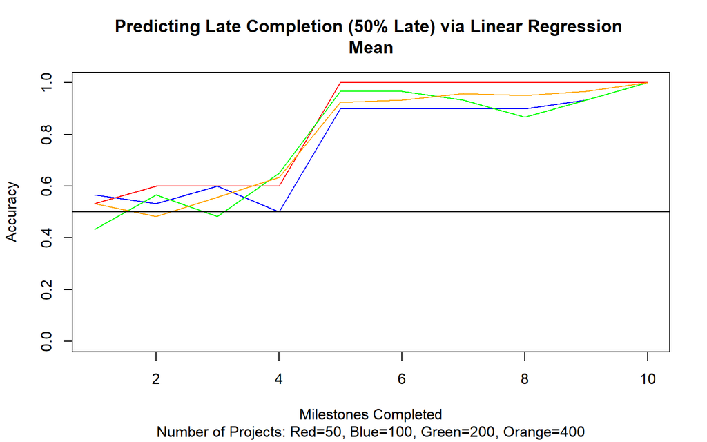

```r
par(mar = c(5, 4, 4, 2) + 0.1)

plot(lravg_acc[,1], type="l", col="red", ylim=c(0,1), xlab="Milestones Completed", ylab="Accuracy"
     ,main="Predicting Late Completion (50% Late) via Linear Regression \nMean", sub="Number of Projects: Red=50, Blue=100, Green=200, Orange=400")
lines(lravg_acc[,2], col="blue")
lines(lravg_acc[,3], col="green")
lines(lravg_acc[,4], col="orange")
abline(h=.5)
```

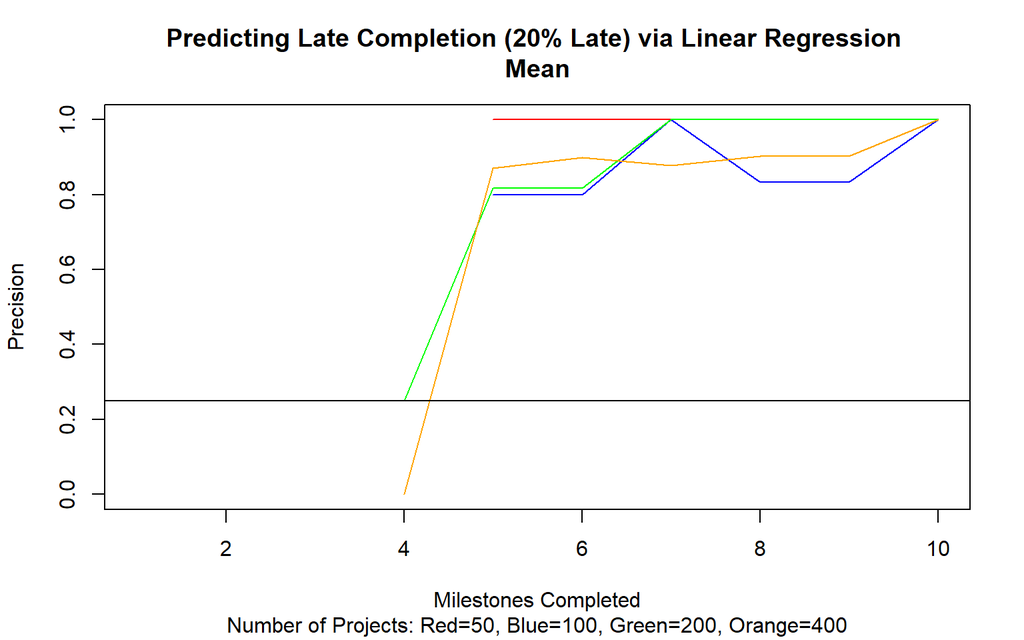

```r
prec_base <- sum(pull(dcx400proj, "LateNum20"))/sum(1-pull(dcx400proj, "LateNum20"))

plot(lravg_prec[,1], type="l", col="red", ylim=c(0,1), xlab="Milestones Completed", ylab="Precision"
     ,main="Predicting Late Completion (20% Late) via Linear Regression \nMean", sub="Number of Projects: Red=50, Blue=100, Green=200, Orange=400")
lines(lravg_prec[,2], col="blue")
lines(lravg_prec[,3], col="green")
lines(lravg_prec[,4], col="orange")
abline(h=prec_base)
```

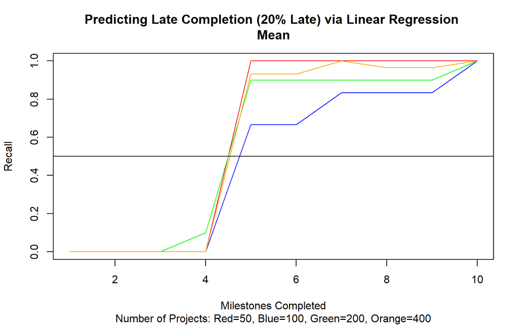

```r
plot(lravg_rec[,1], type="l", col="red", ylim=c(0,1), xlab="Milestones Completed", ylab="Recall"
     ,main="Predicting Late Completion (20% Late) via Linear Regression \nMean", sub="Number of Projects: Red=50, Blue=100, Green=200, Orange=400")
lines(lravg_rec[,2], col="blue")
lines(lravg_rec[,3], col="green")
lines(lravg_rec[,4], col="orange")
abline(h=.5)
```

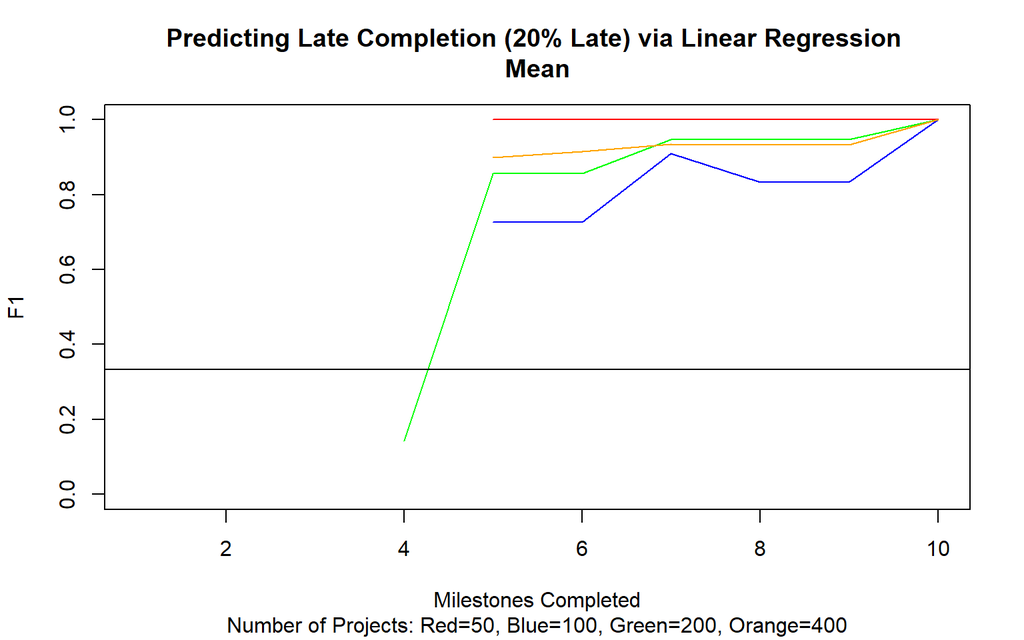

```r
plot(lravg_f1[,1], type="l", col="red", ylim=c(0,1), xlab="Milestones Completed", ylab="F1"
     ,main="Predicting Late Completion (20% Late) via Linear Regression \nMean", sub="Number of Projects: Red=50, Blue=100, Green=200, Orange=400")
lines(lravg_f1[,2], col="blue")
lines(lravg_f1[,3], col="green")
lines(lravg_f1[,4], col="orange")
abline(h=prec_base/(prec_base+.5))
```

```r
par(mar = c(0,0,0,0))
plot(c(0, 1), c(0, 1), ann = F, bty = 'n', type = 'n', xaxt = 'n', yaxt = 'n')
text(x = 0.5, y = 0.5, "Begin Linear Regression Lower Bound Plots", cex = 1.6, col = "black")
```

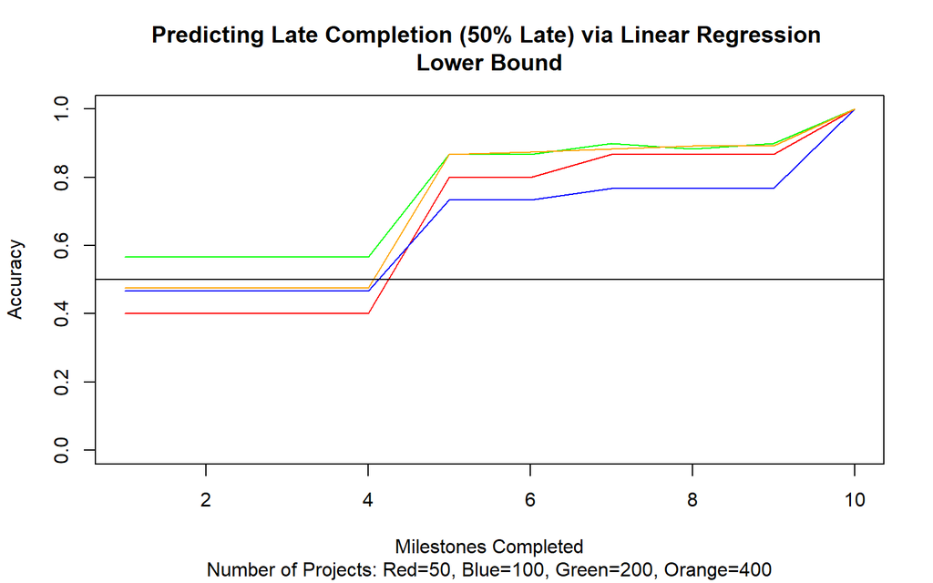

```r
par(mar = c(5, 4, 4, 2) + 0.1)

plot(lrlwr_acc[,1], type="l", col="red", ylim=c(0,1), xlab="Milestones Completed", ylab="Accuracy"
     ,main="Predicting Late Completion (50% Late) via Linear Regression \nLower Bound", sub="Number of Projects: Red=50, Blue=100, Green=200, Orange=400")
lines(lrlwr_acc[,2], col="blue")
lines(lrlwr_acc[,3], col="green")
lines(lrlwr_acc[,4], col="orange")
abline(h=.5)
```

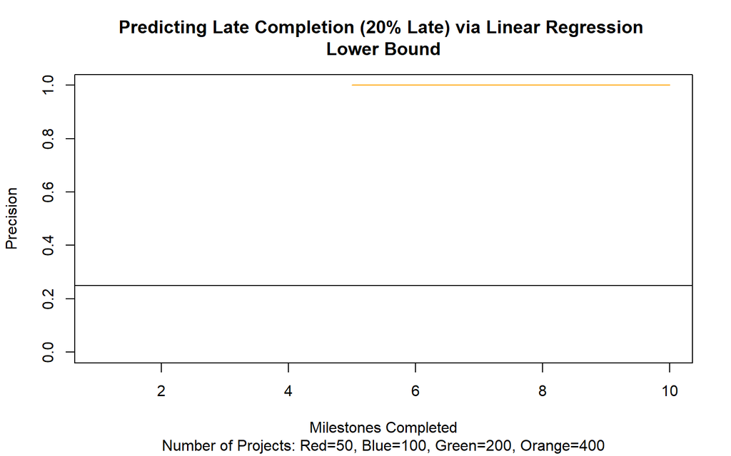

```r
plot(lrlwr_prec[,1], type="l", col="red", ylim=c(0,1), xlab="Milestones Completed", ylab="Precision"
     ,main="Predicting Late Completion (20% Late) via Linear Regression \nLower Bound", sub="Number of Projects: Red=50, Blue=100, Green=200, Orange=400")
lines(lrlwr_prec[,2], col="blue")
lines(lrlwr_prec[,3], col="green")
lines(lrlwr_prec[,4], col="orange")
abline(h=prec_base)
```

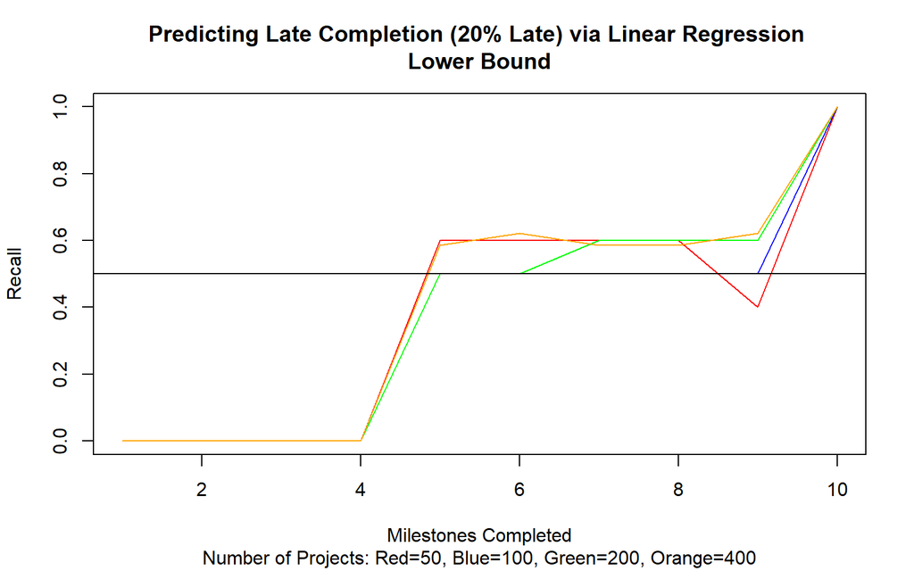

```r
plot(lrlwr_rec[,1], type="l", col="red", ylim=c(0,1), xlab="Milestones Completed", ylab="Recall"
     ,main="Predicting Late Completion (20% Late) via Linear Regression \nLower Bound", sub="Number of Projects: Red=50, Blue=100, Green=200, Orange=400")
lines(lrlwr_rec[,2], col="blue")
lines(lrlwr_rec[,3], col="green")
lines(lrlwr_rec[,4], col="orange")
abline(h=.5)
```

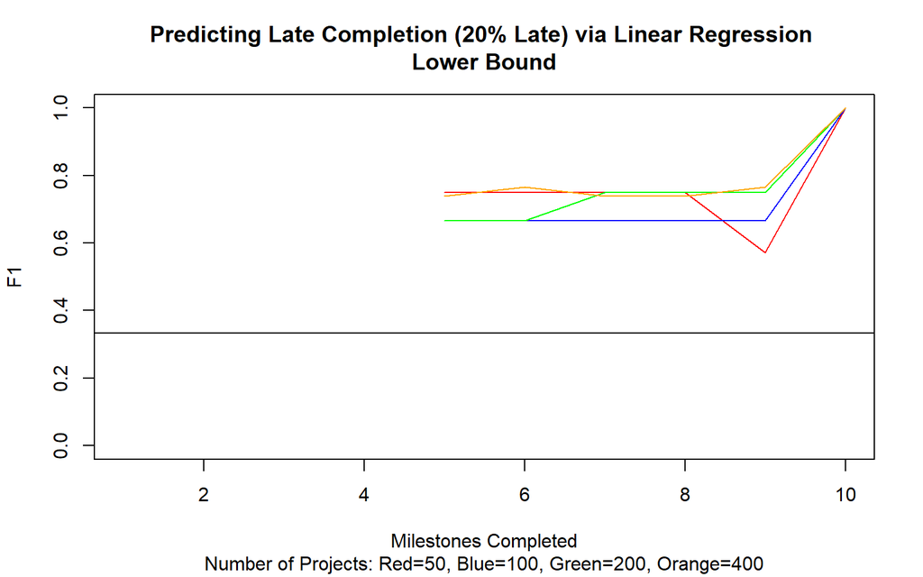

```r
plot(lrlwr_f1[,1], type="l", col="red", ylim=c(0,1), xlab="Milestones Completed", ylab="F1"
     ,main="Predicting Late Completion (20% Late) via Linear Regression \nLower Bound", sub="Number of Projects: Red=50, Blue=100, Green=200, Orange=400")
lines(lrlwr_f1[,2], col="blue")
lines(lrlwr_f1[,3], col="green")
lines(lrlwr_f1[,4], col="orange")
abline(h=prec_base/(prec_base+.5))
```

```r
par(mar = c(0,0,0,0))
plot(c(0, 1), c(0, 1), ann = F, bty = 'n', type = 'n', xaxt = 'n', yaxt = 'n')
text(x = 0.5, y = 0.5, "Begin Boosted Decision Tree Plots", cex = 1.6, col = "black")
```

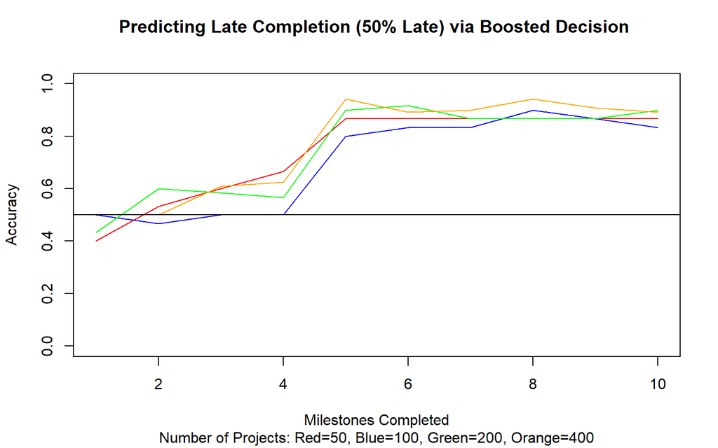

```r
par(mar = c(5, 4, 4, 2) + 0.1)

plot(bdt_acc[,1], type="l", col="red", ylim=c(0,1), xlab="Milestones Completed", ylab="Accuracy"
     ,main="Predicting Late Completion (50% Late) via Boosted Decision \n", sub="Number of Projects: Red=50, Blue=100, Green=200, Orange=400")
lines(bdt_acc[,2], col="blue")
lines(bdt_acc[,3], col="green")
lines(bdt_acc[,4], col="orange")
abline(h=.5)
```

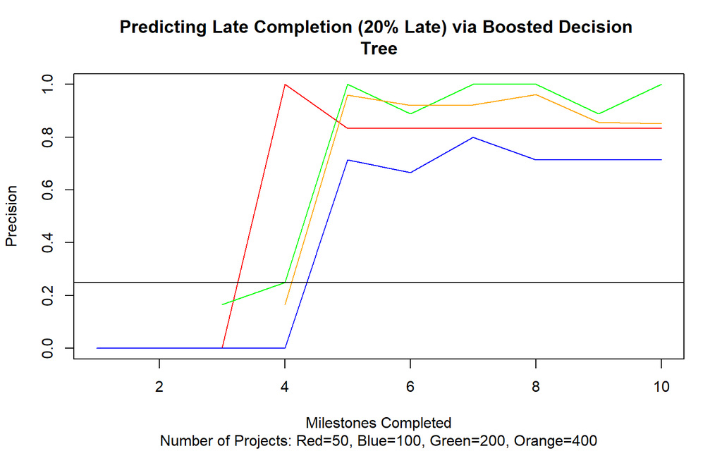

```r
plot(bdt_prec[,1], type="l", col="red", ylim=c(0,1), xlab="Milestones Completed", ylab="Precision"
     ,main="Predicting Late Completion (20% Late) via Boosted Decision \nTree", sub="Number of Projects: Red=50, Blue=100, Green=200, Orange=400")
lines(bdt_prec[,2], col="blue")
lines(bdt_prec[,3], col="green")
lines(bdt_prec[,4], col="orange")
abline(h=prec_base)
```

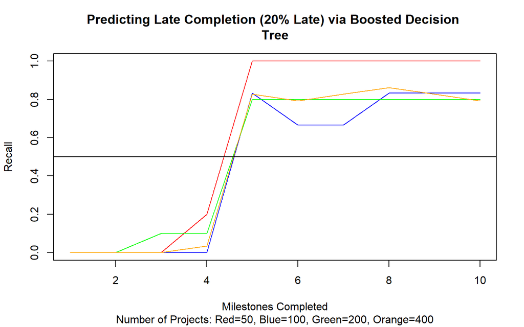

```r
plot(bdt_rec[,1], type="l", col="red", ylim=c(0,1), xlab="Milestones Completed", ylab="Recall"
     ,main="Predicting Late Completion (20% Late) via Boosted Decision \nTree", sub="Number of Projects: Red=50, Blue=100, Green=200, Orange=400")
lines(bdt_rec[,2], col="blue")
lines(bdt_rec[,3], col="green")
lines(bdt_rec[,4], col="orange")
abline(h=.5)
```

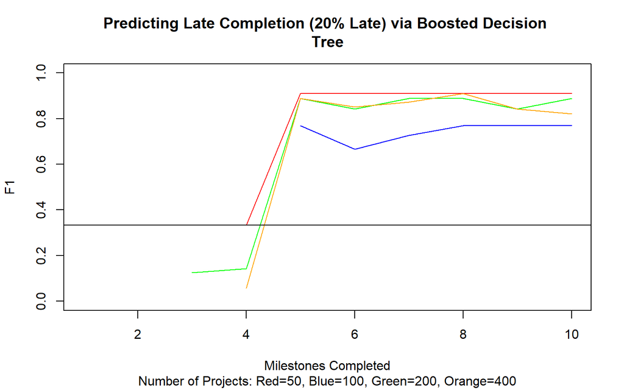

```r
plot(bdt_f1[,1], type="l", col="red", ylim=c(0,1), xlab="Milestones Completed", ylab="F1"
     ,main="Predicting Late Completion (20% Late) via Boosted Decision \nTree", sub="Number of Projects: Red=50, Blue=100, Green=200, Orange=400")
lines(bdt_f1[,2], col="blue")
lines(bdt_f1[,3], col="green")
lines(bdt_f1[,4], col="orange")
abline(h=prec_base/(prec_base+.5))
```

```r
par(mar = c(0,0,0,0))
plot(c(0, 1), c(0, 1), ann = F, bty = 'n', type = 'n', xaxt = 'n', yaxt = 'n')
text(x = 0.5, y = 0.5, "Begin Logistic Regression Plots", cex = 1.6, col = "black")
```

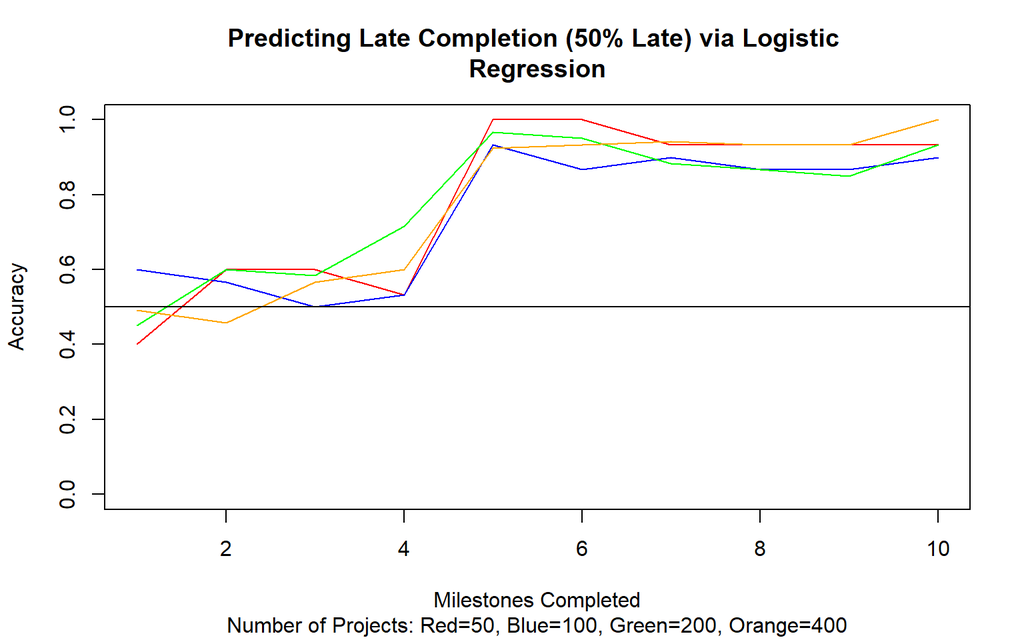

```r
par(mar = c(5, 4, 4, 2) + 0.1)

plot(log_acc[,1], type="l", col="red", ylim=c(0,1), xlab="Milestones Completed", ylab="Accuracy"
     ,main="Predicting Late Completion (50% Late) via Logistic \nRegression", sub="Number of Projects: Red=50, Blue=100, Green=200, Orange=400")
lines(log_acc[,2], col="blue")
lines(log_acc[,3], col="green")
lines(log_acc[,4], col="orange")
abline(h=.5)
```

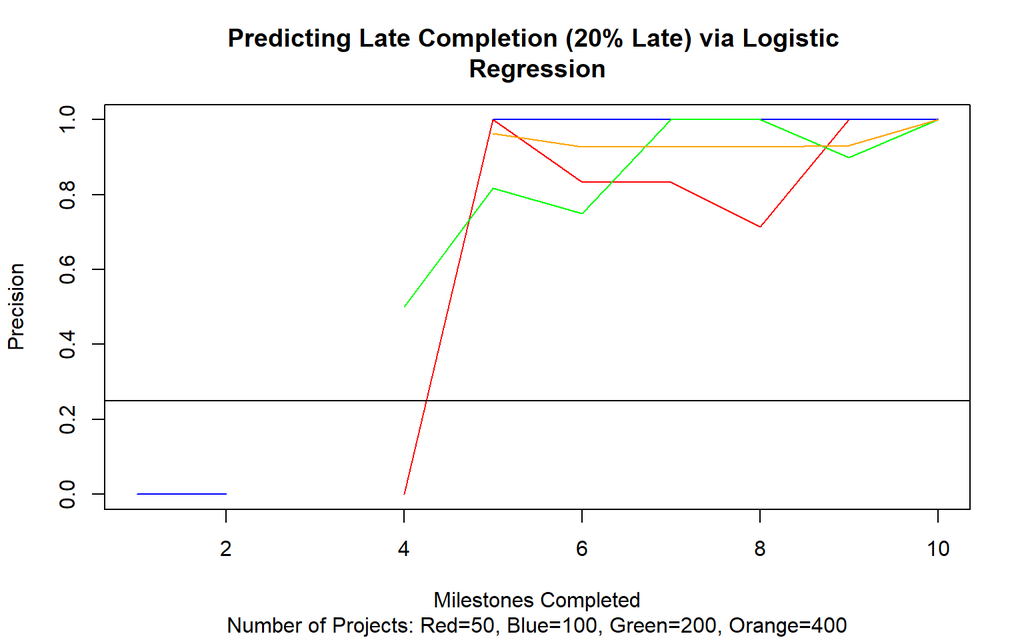

```r
plot(log_prec[,1], type="l", col="red", ylim=c(0,1), xlab="Milestones Completed", ylab="Precision"
     ,main="Predicting Late Completion (20% Late) via Logistic \nRegression", sub="Number of Projects: Red=50, Blue=100, Green=200, Orange=400")
lines(log_prec[,2], col="blue")
lines(log_prec[,3], col="green")
lines(log_prec[,4], col="orange")
abline(h=prec_base)
```

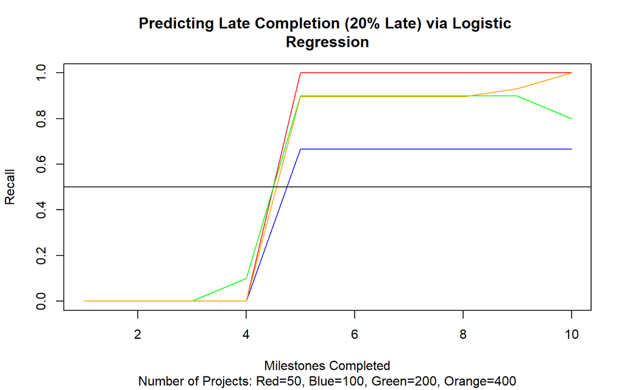

```r
plot(log_rec[,1], type="l", col="red", ylim=c(0,1), xlab="Milestones Completed", ylab="Recall"
     ,main="Predicting Late Completion (20% Late) via Logistic \nRegression", sub="Number of Projects: Red=50, Blue=100, Green=200, Orange=400")
lines(log_rec[,2], col="blue")
lines(log_rec[,3], col="green")
lines(log_rec[,4], col="orange")
abline(h=.5)
```

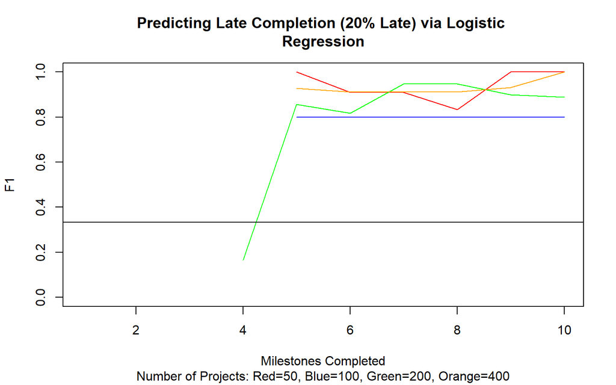

```r
plot(log_f1[,1], type="l", col="red", ylim=c(0,1), xlab="Milestones Completed", ylab="F1"
     ,main="Predicting Late Completion (20% Late) via Logistic \nRegression", sub="Number of Projects: Red=50, Blue=100, Green=200, Orange=400")
lines(log_f1[,2], col="blue")
lines(log_f1[,3], col="green")
lines(log_f1[,4], col="orange")
abline(h=prec_base/(prec_base+.5))
```

All of these plots tells pretty much the same story. Once we surpass Milestone 5 (Beneficial.Use), we have a very accurate model for predicting Total Project Completion Time. Why is this?

```r
disp <- data.frame(dcx.mean.final, paste(round(dcx.mean.final/sum(dcx.mean.final)*100,0), "%", sep=""), dcx.sd[dcx.sd.new>0], dcx.sd.final, paste(round(dcx.sd.final/sum(dcx.sd.final)*100,0), "%", sep=""))
names(disp) <- c("Mean", "Percent of Total Mean", "Original St Dev", "Final St Dev", "Percent of Total St Dev")
disp
```

|  | Mean | Percent of Total Mean | Original St Dev | Final St Dev | Percent of Total St Dev |
| --- | --- | --- | --- | --- | --- |
| Charter.Approved | 34.75 | 5% | 42.91367 | 42.91367 | 5% |
| Design.Kickoff | 50.00 | 8% | 78.80990 | 78.80990 | 9% |
| Issue.for.Construction.Documents..IFC. | 42.00 | 6% | 29.81610 | 29.81610 | 4% |
| Construction.Start | 169.00 | 26% | 135.50277 | 135.50277 | 16% |
| Beneficial.Use | 249.00 | 38% | NA | 386.42383 | 46% |
| IST.Complete | 7.00 | 1% | NA | 10.86332 | 1% |
| Security.Lockdown | 33.00 | 5% | NA | 51.21280 | 6% |
| Turnover.to.Ops | 8.00 | 1% | NA | 12.41522 | 1% |
| Colo.Ready | 11.00 | 2% | NA | 17.07093 | 2% |
| RTEG | 49.00 | 8% | NA | 76.04324 | 9% |

Milestone 5 is the most significant milestone because it makes up 38% of the average and 46% of all the variation in project completion times. Unfortunately, this is also one of the milestones for which we only had one record. Therefore, it’s very risky to make any decisions with this information. However, it’s obvious that our framework works extremely well. All we need are a few more data points.